# Project

2024-11-09

install.packages(“tidyverse”)

```r
library(tidyverse)
# Load the dataset
insurance_data <- read.csv("/Users/dineshyaadavm/Desktop/insurance.csv")
```

```r
# Display the first few rows
head(insurance_data)
```

```
##   age    sex  bmi children smoker    region expenses
## 1  19 female 27.9        0    yes southwest 16884.92
## 2  18   male 33.8        1     no southeast  1725.55
## 3  28   male 33.0        3     no southeast  4449.46
## 4  33   male 22.7        0     no northwest 21984.47
## 5  32   male 28.9        0     no northwest  3866.86
## 6  31 female 25.7        0     no southeast  3756.62
```

```r
# Get summary statistics
summary(insurance_data)
```

```
##       age            sex                 bmi           children
##  Min.   :18.00   Length:1338        Min.   :16.00   Min.   :0.000
##  1st Qu.:27.00   Class :character   1st Qu.:26.30   1st Qu.:0.000
##  Median :39.00   Mode  :character   Median :30.40   Median :1.000
##  Mean   :39.21                      Mean   :30.67   Mean   :1.095
##  3rd Qu.:51.00                      3rd Qu.:34.70   3rd Qu.:2.000
##  Max.   :64.00                      Max.   :53.10   Max.   :5.000
##     smoker             region             expenses
##  Length:1338        Length:1338        Min.   : 1122
##  Class :character   Class :character   1st Qu.: 4740
##  Mode  :character   Mode  :character   Median : 9382
##                                        Mean   :13270
##                                        3rd Qu.:16640
##                                        Max.   :63770
```

```r
# Check the structure of the dataset
str(insurance_data)
```

```
## 'data.frame':    1338 obs. of  7 variables:
##  $ age     : int  19 18 28 33 32 31 46 37 37 60 ...
##  $ sex     : chr  "female" "male" "male" "male" ...
##  $ bmi     : num  27.9 33.8 33 22.7 28.9 25.7 33.4 27.7 29.8 25.8 ...
##  $ children: int  0 1 3 0 0 0 1 3 2 0 ...
##  $ smoker  : chr  "yes" "no" "no" "no" ...
##  $ region  : chr  "southwest" "southeast" "southeast" "northwest" ...
##  $ expenses: num  16885 1726 4449 21984 3867 ...
```

## From the summary, here are some key inferences:

Age: The age range is between 18 and 64, with a median of 39 and a mean of 39.21. This suggests a balanced age distribution with a slight skew toward older ages.

Sex: This variable is categorical with entries labeled as “female” and “male”. The summary doesn’t specify proportions, but gender could be an interesting variable to explore in relation to expenses or BMI.

BMI (Body Mass Index): BMI ranges from 16.0 to 53.1, with a median of 30.4 and a mean of 30.67. A median BMI above 30 indicates that many individuals in this dataset are likely in the overweight or obese categories, which could correlate with higher health expenses.

Children: The number of children ranges from 0 to 5, with a mean of about 1.1. A median of 1 child suggests that most individuals have 0 or 1 child, though a smaller group has more.

Smoker: This is a categorical variable with values “yes” and “no.” Given the likely influence of smoking status on health expenses, this will be an essential factor for further analysis.

Region: This variable categorizes individuals by region, with four potential values (“southwest,” “southeast,” “northwest,” and likely “northeast”). Different regions might show variations in health expenses, perhaps due to lifestyle or healthcare access differences.

Expenses: Health-related expenses range widely, from 1,122 to 63,770. The mean expense is 13,270, but with a median of 9,382, indicating a right-skewed distribution—some individuals have notably high health costs, possibly due to factors like smoking or higher BMI.

This dataset appears well-suited for regression analysis to explore how age, BMI, children, smoking status, and region affect health-related expenses.

```r
# Check for missing values
colSums(is.na(insurance_data))
```

```
##      age      sex      bmi children   smoker   region expenses
##        0        0        0        0        0        0        0
```

```r
# Convert categorical variables to factors
insurance_data$sex <- as.factor(insurance_data$sex)
insurance_data$smoker <- as.factor(insurance_data$smoker)
insurance_data$region <- as.factor(insurance_data$region)
```

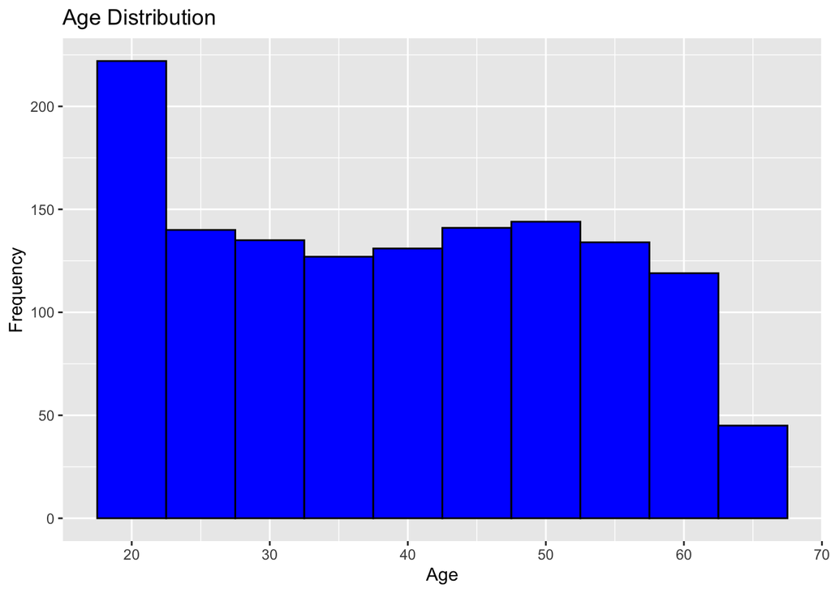

```r
# Histogram of age
ggplot(insurance_data, aes(x = age)) +
    geom_histogram(binwidth = 5, fill = "blue", color = "black") +
    labs(title = "Age Distribution", x = "Age", y = "Frequency")
```

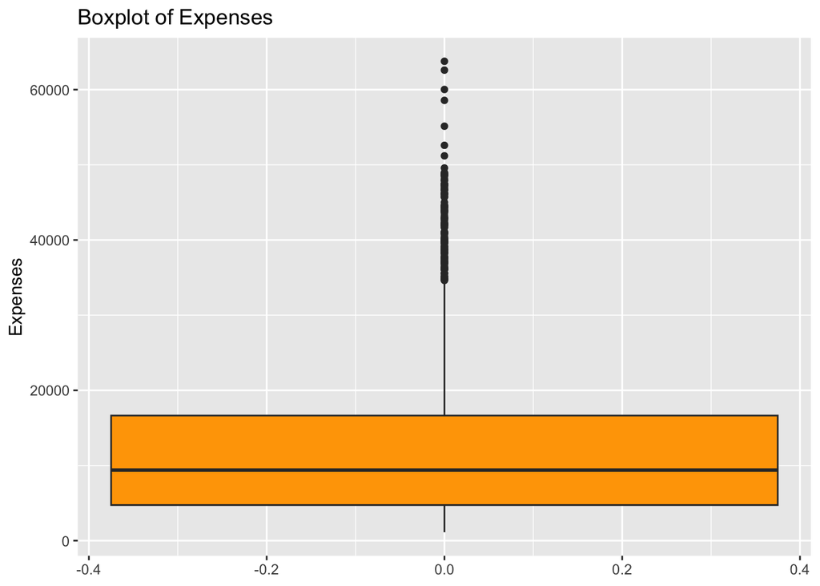

```r
# Boxplot of expenses
ggplot(insurance_data, aes(y = expenses)) +
    geom_boxplot(fill = "orange") +
    labs(title = "Boxplot of Expenses", y = "Expenses")
```

Boxplot of Expenses: The boxplot has a long vertical line, indicating a wide range of expenses in the dataset. The box portion of the plot is relatively short, suggesting that the majority of the expenses fall within a narrower range. The presence of several outliers, as indicated by the points beyond the whiskers, suggests that there are some individuals with unusually high expenses compared to the rest of the population. This distribution of expenses is typical of insurance data, where a large portion of the population may have relatively low expenses, but a small subset can have significantly higher expenses.

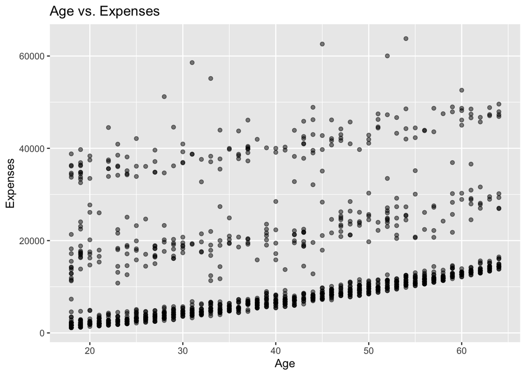

```r
# Scatter plot of age vs expenses
ggplot(insurance_data, aes(x = age, y = expenses)) +
    geom_point(alpha = 0.5) +
    labs(title = "Age vs. Expenses", x = "Age", y = "Expenses")
```

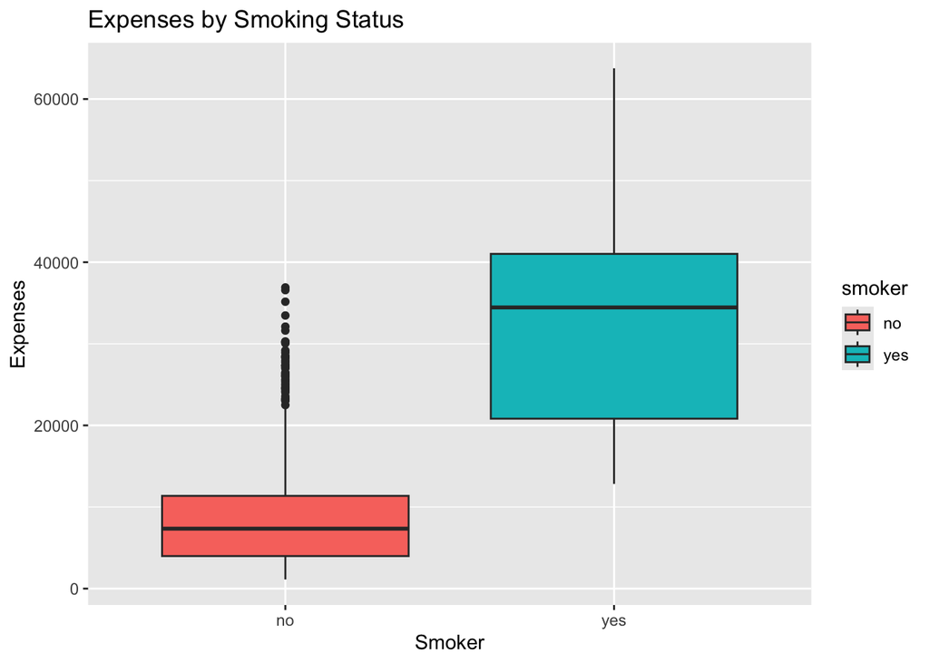

```r
# Boxplot of expenses by smoker status
ggplot(insurance_data, aes(x = smoker, y = expenses, fill = smoker)) +
    geom_boxplot() +
    labs(title = "Expenses by Smoking Status", x = "Smoker", y = "Expenses")
```

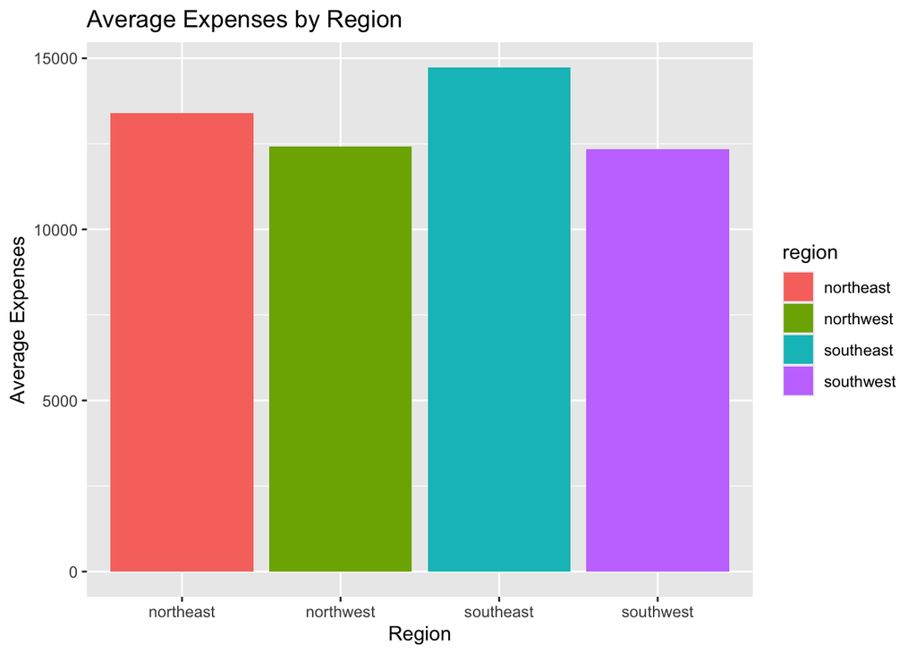

```r
# Bar plot of average expenses by region
insurance_data %>%
    group_by(region) %>%
    summarize(avg_expenses = mean(expenses)) %>%
    ggplot(aes(x = region, y = avg_expenses, fill = region)) +
    geom_bar(stat = "identity") +
    labs(title = "Average Expenses by Region", x = "Region", y = "Average Expenses")
```

```r
# Calculate Q1 (25th percentile) and Q3 (75th percentile)
Q1 <- quantile(insurance_data$expenses, 0.25)
Q3 <- quantile(insurance_data$expenses, 0.75)

# Calculate IQR
IQR_value <- IQR(insurance_data$expenses)

# Determine the lower and upper bounds for outliers
lower_bound <- Q1 - 1.5 * IQR_value
upper_bound <- Q3 + 1.5 * IQR_value

# Identify outliers
outliers <- insurance_data %>%
  filter(expenses < lower_bound | expenses > upper_bound)

# Display outliers
print(outliers)
```

```
##     age    sex  bmi children smoker    region expenses
## 1    27   male 42.1        0    yes southeast 39611.76
## 2    30   male 35.3        0    yes southwest 36837.47
## 3    34 female 31.9        1    yes northeast 37701.88
## 4    31   male 36.3        2    yes southwest 38711.00
## 5    22   male 35.6        0    yes southwest 35585.58
## 6    28   male 36.4        1    yes southwest 51194.56
## 7    35   male 36.7        1    yes northeast 39774.28
## 8    60   male 39.9        0    yes southwest 48173.36
## 9    36   male 35.2        1    yes southeast 38709.18
## 10   36   male 34.4        0    yes southeast 37742.58
## 11   58   male 37.0        2    yes northwest 47496.49
## 12   22   male 37.6        1    yes southeast 37165.16
## 13   37 female 34.8        2    yes southwest 39836.52
## 14   57 female 31.2        0    yes northwest 43578.94
```

[output cut: 125 more lines]

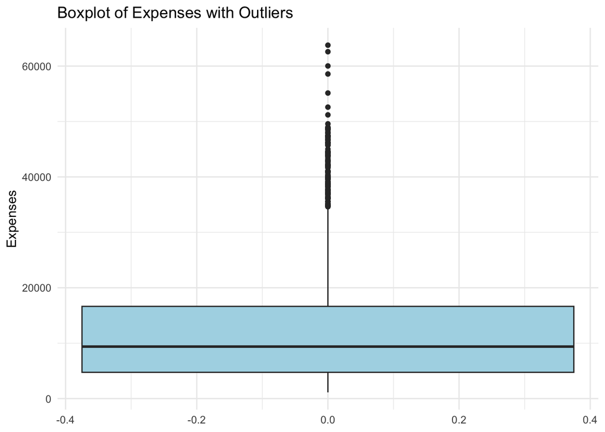

```r
# Boxplot to visualize outliers
ggplot(insurance_data, aes(y = expenses)) +
    geom_boxplot(fill = "lightblue") +
    labs(title = "Boxplot of Expenses with Outliers", y = "Expenses") +
    theme_minimal()
```

```r
# Calculate Z-scores for expenses
z_scores <- scale(insurance_data$expenses)

# Identify outliers based on Z-scores
outliers_z <- insurance_data[abs(z_scores) > 3, ]

# Display outliers based on Z-scores
print(outliers_z)
```

```
##      age    sex  bmi children smoker    region expenses
## 35    28   male 36.4        1    yes southwest 51194.56
## 544   54 female 47.4        0    yes southeast 63770.43
## 578   31 female 38.1        1    yes northeast 58571.07
## 820   33 female 35.5        0    yes northwest 55135.40
## 1147  60   male 32.8        0    yes southwest 52590.83
## 1231  52   male 34.5        3    yes northwest 60021.40
## 1301  45   male 30.4        0    yes southeast 62592.87
```

```r
# Calculate Z-scores for expenses
z_scores <- scale(insurance_data$expenses)

# Remove outliers based on Z-scores
insurance_data_cleaned_z <- insurance_data[abs(z_scores) <= 3, ]

# Display the cleaned dataset
print(dim(insurance_data_cleaned_z))
```

```
## [1] 1331    7
```

```r
# Check summary of cleaned dataset
summary(insurance_data_cleaned_z)
```

```
##       age            sex           bmi           children     smoker
##  Min.   :18.00   female:659   Min.   :16.00   Min.   :0.000   no :1064
##  1st Qu.:26.00   male  :672   1st Qu.:26.20   1st Qu.:0.000   yes: 267
##  Median :39.00                Median :30.30   Median :1.000
##  Mean   :39.19                Mean   :30.64   Mean   :1.097
##  3rd Qu.:51.00                3rd Qu.:34.60   3rd Qu.:2.000
##  Max.   :64.00                Max.   :53.10   Max.   :5.000
##        region       expenses
##  northeast:323   Min.   : 1122
##  northwest:323   1st Qu.: 4720
##  southeast:362   Median : 9302
##  southwest:323   Mean   :13037
##                  3rd Qu.:16359
##                  Max.   :49578
```

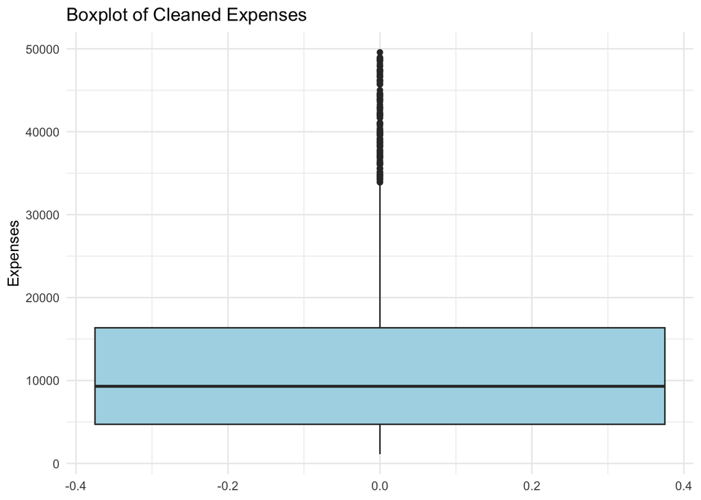

```r
# Boxplot of cleaned expenses to visualize
ggplot(insurance_data_cleaned_z, aes(y = expenses)) +
    geom_boxplot(fill = "lightblue") +
    labs(title = "Boxplot of Cleaned Expenses", y = "Expenses") +
    theme_minimal()
```

```r
# Convert categorical variables to factors

insurance_data$sex <- as.factor(insurance_data$sex)
insurance_data$smoker <- as.factor(insurance_data$smoker)
insurance_data$region <- as.factor(insurance_data$region)

# Fit the multiple linear regression model
model <- lm(expenses ~ age * bmi + smoker + children + region + sex, data = insurance_data)

# Display the summary of the model
model_summary <- summary(model)

conf_intervals <- confint(model)

# Print model summary and confidence intervals
print(model_summary)
```

```
##
## Call:
## lm(formula = expenses ~ age * bmi + smoker + children + region +
##     sex, data = insurance_data)
##
## Residuals:
##      Min       1Q   Median       3Q      Max
## -11301.3  -2842.9   -984.2   1385.4  29982.4
##
## Coefficients:
##                   Estimate Std. Error t value Pr(>|t|)
## (Intercept)     -1.169e+04  2.499e+03  -4.677 3.21e-06 ***
## age              2.502e+02  6.117e+01   4.090 4.58e-05 ***
## bmi              3.309e+02  8.022e+01   4.125 3.93e-05 ***
## smokeryes        2.385e+04  4.134e+02  57.690  < 2e-16 ***
## children         4.755e+02  1.379e+02   3.449  0.00058 ***
## regionnorthwest -3.515e+02  4.766e+02  -0.738  0.46088
## regionsoutheast -1.034e+03  4.792e+02  -2.157  0.03119 *
## regionsouthwest -9.602e+02  4.782e+02  -2.008  0.04483 *
## sexmale         -1.320e+02  3.331e+02  -0.396  0.69189
## age:bmi          2.161e-01  1.942e+00   0.111  0.91141
## ---
## Signif. codes:  0 '***' 0.001 '**' 0.01 '*' 0.05 '.' 0.1 ' ' 1
##
## Residual standard error: 6064 on 1328 degrees of freedom
## Multiple R-squared:  0.7509, Adjusted R-squared:  0.7492
## F-statistic: 444.9 on 9 and 1328 DF,  p-value: < 2.2e-16
```

```r
print(conf_intervals)
```

```
##                         2.5 %       97.5 %
## (Intercept)     -16587.788503 -6784.597553
## age                130.166061   370.159131
## bmi                173.572559   488.326925
## smokeryes        23037.512375 24659.458174
## children           205.051282   745.950279
## regionnorthwest  -1286.445813   583.390824
## regionsoutheast  -1973.664034   -93.556663
## regionsouthwest  -1898.278628   -22.202543
## sexmale           -785.533856   521.450125
## age:bmi             -3.594128     4.026395
```

Model Fit: The adjusted R-squared value of 0.7492 indicates that the model explains approximately 74.92% of the variation in insurance expenses. This suggests a reasonably good model fit, with the selected independent variables being able to account for a significant portion of the variability in expenses.

Statistically Significant Predictors: Age, BMI, smoking status, and number of children are all statistically significant predictors of insurance expenses (p-value < 0.001). Smoking status has the largest effect, with smokers incurring approximately $23,000 to $24,659 higher expenses compared to non-smokers, all else being equal. Age and BMI also have significant positive effects, indicating that older individuals and those with higher BMIs tend to have higher insurance expenses. The number of children also has a positive and significant effect on expenses, with each additional child increasing expenses by around $205 to $746.

Non-Significant Predictors: The interaction between age and BMI is not statistically significant, suggesting that the effects of these two variables on expenses are independent of each other. Sex (male) is also not a significant predictor of expenses, indicating that gender does not have a significant impact on insurance costs after accounting for the other factors.

Overall, the regression analysis highlights the importance of age, BMI, smoking status, and the number of children as key drivers of insurance expenses. The regional differences also suggest that location-specific factors may play a role in determining insurance costs.

```r
# Load necessary library
library(lmtest)
# Durbin-Watson test
dw_test <- dwtest(model)
print(dw_test)
```

```
##
##  Durbin-Watson test
##
## data:  model
## DW = 2.0881, p-value = 0.9467
## alternative hypothesis: true autocorrelation is greater than 0
```

The results of the Durbin-Watson test provide valuable insights into the presence of autocorrelation in the regression model’s residuals.

Results Interpretation: Durbin-Watson Statistic (DW): The DW statistic is approximately 2.0881. Values close to 2 suggest that there is no autocorrelation. Since the value is slightly above 2, it indicates a very low likelihood of positive autocorrelation.

P-value: The p-value of 0.9467 is quite high. A high p-value (typically above 0.05) indicates that we do not reject the null hypothesis of the test, which states that there is no positive autocorrelation in the residuals.

Conclusion: Given that the DW statistic is close to 2 and the p-value is very high, you can interpret the coefficients of the regression model (e.g., effects of age, BMI, smoking status, etc.) without worrying about the influence of autocorrelation skewing the results. This suggests that the residuals are independent of each other, which is a favorable condition for the validity of the regression analysis.

Implications: The absence of autocorrelation means that the assumption of independence among residuals is satisfied. This enhances the reliability of the p-values and confidence intervals for the regression coefficients. You can proceed with interpreting the regression model with greater confidence, knowing that autocorrelation is not a concern in this context

```r
# Breusch-Pagan test
library(lmtest)
bptest_result <- bptest(model)
print(bptest_result)
```

```
##
##  studentized Breusch-Pagan test
##
## data:  model
## BP = 121.94, df = 9, p-value < 2.2e-16
```

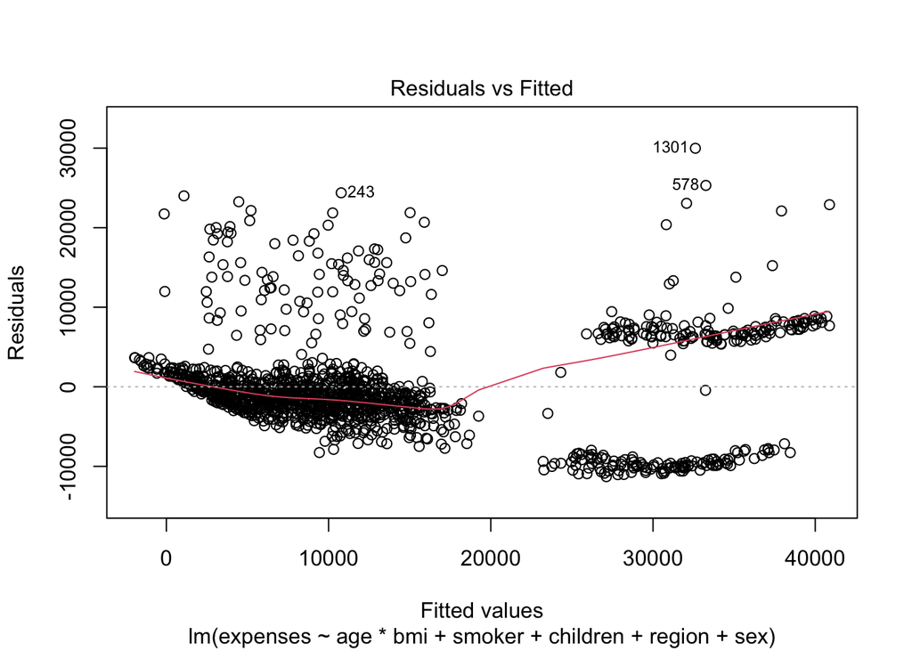

```r
# Plotting residuals
plot(model, which = 1)  # Residuals vs Fitted values
```

# Based on the output of the Breusch-Pagan test, the p-value is less than 2.2e-16, which is extremely small. This means that we can reject the null hypothesis of constant variance with a very high degree of confidence. In other words, the results suggest that the variance of the residuals is not constant, and there is evidence of heteroscedasticity in the data.

The plot of “Residuals vs Fitted” values also provides a visual representation of the heteroscedasticity. The plot shows a clear pattern, where the spread of the residuals appears to increase as the fitted values increase. This is a typical sign of heteroscedasticity, where the variance of the residuals is not constant across the range of the fitted values.

To address the issue of heteroscedasticity, you may want to consider using a modeling approach that relaxes the assumption of constant variance, such as weighted least squares regression or robust standard errors. Alternatively, you could explore transforming the variables or using a different model specification to better account for the non-constant variance in the data.

```r
# Load necessary library
library(car)
# Calculate VIF
vif_values <- vif(model)
```

```
## there are higher-order terms (interactions) in this model
## consider setting type = 'predictor'; see ?vif
```

```r
print(vif_values)
```

```
##               GVIF Df GVIF^(1/(2*Df))
## age      26.852725  1        5.181962
## bmi       8.701890  1        2.949897
## smoker    1.012554  1        1.006257
## children  1.004159  1        1.002077
## region    1.102981  3        1.016470
## sex       1.009249  1        1.004614
## age:bmi  37.469300  1        6.121217
```

The GVIF (Generalized Variance Inflation Factor) values provided indicate the extent of multicollinearity in the regression model. Multicollinearity occurs when the independent variables in a regression model are highly correlated with each other, which can lead to unstable and unreliable estimates of the regression coefficients.

Let’s interpret the GVIF values for each variable:

1. age: The GVIF value for age is 26.852725, which is quite high. The GVIF^(1/(2*Df)) value of 5.181962 suggests that the standard errors of the age coefficient may be inflated by a factor of around 5.18 due to multicollinearity.
2. bmi: The GVIF value for bmi is 8.701890, which is also relatively high. The GVIF^(1/(2*Df)) value of 2.949897 indicates that the standard errors of the bmi coefficient may be inflated by a factor of around 2.95.
3. smoker, children, and sex: These variables have relatively low GVIF values (less than 1.5), suggesting that multicollinearity is not a major concern for these variables.
4. region: The GVIF value for region is 1.102981, which is still relatively low. The GVIF^(1/(2*Df)) value of 1.016470 indicates that the standard errors of the region coefficients may be inflated by a factor of around 1.02.
5. age:bmi: The GVIF value for the interaction term age:bmi is 37.469300, which is very high. The GVIF^(1/(2*Df)) value of 6.121217 suggests that the standard errors of the age:bmi coefficient may be inflated by a factor of around 6.12.

The high GVIF values for age and the age:bmi interaction term indicate that there is substantial multicollinearity in the model, likely due to the strong correlation between age and bmi. This multicollinearity can lead to unstable and unreliable estimates of the regression coefficients, as well as inflated standard errors.

To address this issue, you may want to consider the following approaches:

1. Centering or standardizing the continuous variables (age and bmi) to reduce multicollinearity.
2. Removing one of the highly correlated variables (age or bmi) from the model.
3. Exploring alternative model specifications that better account for the relationship between the variables.
4. Using techniques such as ridge regression or principal component regression to address multicollinearity.

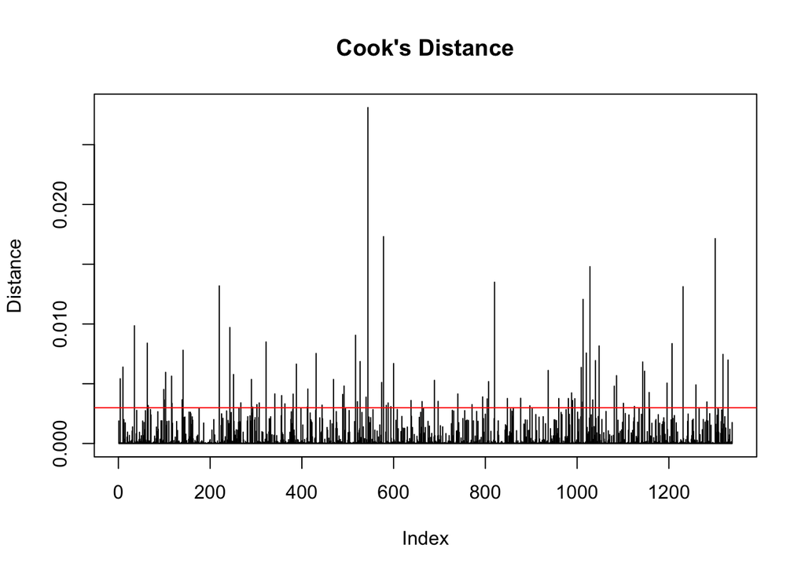

```r
# Cook's Distance
cooks_distance <- cooks.distance(model)

# Plot Cook's Distance
plot(cooks_distance, type = "h", main = "Cook's Distance", ylab = "Distance")
abline(h = 4 / length(cooks_distance), col = "red")  # threshold line
```

# The image shows a plot of “Cook’s Distance” against an index. Cook’s Distance is a metric used in regression analysis to identify influential data points that have a disproportionate impact on the model’s results.

Based on the plot, we can make the following observations:

The majority of the data points have a relatively low Cook’s Distance, indicating that they have little influence on the regression model. However, there are several data points that stand out with much higher Cook’s Distance values. These are potential outliers or influential data points that may be worth investigating further. The plot shows a few distinct peaks where the Cook’s Distance values are significantly higher than the surrounding data points. These are the most influential data points that are likely to have a substantial impact on the regression model. The presence of these high Cook’s Distance values suggests that the data may contain some outliers or influential observations that could be affecting the model’s performance. It would be prudent to examine these data points more closely and consider whether they should be retained, removed, or handled in some other way to improve the reliability of the regression analysis. In summary, this plot provides a visual representation of the influence of individual data points on the regression model. By identifying the most influential observations, the analyst can make informed decisions about how to address potential issues in the data and improve the accuracy and robustness of the regression analysis.